# R Notebook

# Entrenamiento de Modelos

## Entrenamiento de Modelos No Supervisados

```r
library(cluster)
library(factoextra)
X <- df_cleaned %>% select(-Depression, -id)
y <- df_cleaned$Depression

scaler <- preProcess(X, method = c("center", "scale"))
X_scaled <- predict(scaler, X)

best_k <- 0
best_score <- -1

for (k in 2:10) {
  kmeans_model <- kmeans(X_scaled, centers = k, nstart = 25)
  silhouette_avg <- mean(silhouette(kmeans_model$cluster, dist(X_scaled))[, 3])

  cat("K =", k, ", Silhouette Score =", silhouette_avg, "\n")

  if (silhouette_avg > best_score) {
    best_k <- k
    best_score <- silhouette_avg
  }
}
```

```
K = 2 , Silhouette Score = 0.05028851
K = 3 , Silhouette Score = -0.0116932
K = 4 , Silhouette Score = 0.06601295
K = 5 , Silhouette Score = 0.01424933
K = 6 , Silhouette Score = 0.06969037
K = 7 , Silhouette Score = 0.02743261
K = 8 , Silhouette Score = 0.066881
K = 9 , Silhouette Score = 0.05122757
K = 10 , Silhouette Score = 0.05691962
```

```r
cat("\nMejor número de clusters:", best_k, "con Silhouette Score =", best_score, "\n")
```

```
Mejor número de clusters: 6 con Silhouette Score = 0.06969037
```

```r
kmeans_model <- kmeans(X_scaled, centers = 9, nstart = 25)

df_cleaned$Cluster <- kmeans_model$cluster

cluster_analysis <- df_cleaned %>%
  group_by(Cluster) %>%
  summarise(Depression_Mean = mean(Depression, na.rm = TRUE))

print(cluster_analysis)
```

| Cluster | Depression_Mean |
| --- | --- |
| 1 | 0.5313653 |
| 2 | 0.5798561 |
| 3 | 0.5345489 |
| 4 | 0.5358932 |
| 5 | 0.2270732 |
| 6 | 0.8402067 |
| 7 | 0.5000000 |
| 8 | 0.5306958 |
| 9 | 0.7180959 |

```r
NA
```

A continuación, analizaremos las principales variables que han influido en la clasificación de los clusters.

```r
library(dplyr)

# Definir clusters de alto y bajo riesgo
high_risk_clusters <- c(0, 6)
low_risk_cluster <- c(7)

# Calcular las medias para los clusters de alto y bajo riesgo
high_risk_means <- df_cleaned %>%
  filter(Cluster %in% high_risk_clusters) %>%
  summarise(across(where(is.numeric), mean, na.rm = TRUE)) %>%
  t() %>%
  as.data.frame()
low_risk_means <- df_cleaned %>%
  filter(Cluster %in% low_risk_cluster) %>%
  summarise(across(where(is.numeric), mean, na.rm = TRUE)) %>%
  t() %>%
  as.data.frame()

# Crear un data frame con las variables y las medias
comparison <- data.frame(
  Variable = rownames(high_risk_means),
  High_Risk = unlist(high_risk_means),
  Low_Risk = unlist(low_risk_means),
  row.names = NULL
)

# Filtrar columnas relevantes
comparison <- comparison %>%
  filter(!(Variable %in% c("id", "Cluster", "Depression")))

# Calcular la diferencia y ordenar
comparison <- comparison %>%
  mutate(Difference = abs(High_Risk - Low_Risk)) %>%
  arrange(desc(Difference)) %>%
  slice(1:10)

print("Top 10 variables con mayor diferencia:")
```

```
[1] "Top 10 variables con mayor diferencia:"
```

```r
print(comparison)
```

| Variable | High_Risk | Low_Risk | Difference |
| --- | --- | --- | --- |
| Work Pressure | 0.000000000 | 5.0 | 5.0000000 |
| Job Satisfaction | 0.000000000 | 4.0 | 4.0000000 |
| Academic Pressure | 3.878656331 | 0.0 | 3.8786563 |
| Study Satisfaction | 2.447751938 | 0.0 | 2.4477519 |
| Work/Study Hours | 7.790387597 | 5.5 | 2.2903876 |
| Satisfaction Index | 2.447751938 | 4.0 | 1.5522481 |
| Age | 26.991214470 | 28.0 | 1.0087855 |
| DegreeClass 12 | 0.006925065 | 1.0 | 0.9930749 |
| Stress Index | 7.716279070 | 8.5 | 0.7837209 |
| `Family History of Mental Illness`Yes | 0.500051680 | 0.0 | 0.5000517 |

Stress Index: Es una de las variables sintéticas que mide la presión general en la vida del individuo. Se define como la suma de Academic Pressure, Work Pressure y Financial Stress.

Age: La edad parece ser un factor crucial. Desde un punto de vista funcional, es posible que, a menor edad, haya menos herramientas para gestionar la presión, lo que aumenta la probabilidad de sufrir depresión.

Work/Study Hours: A mayor número de horas de trabajo/estudio, mayores son las posibilidades de sufrir depresión.

Academic Pressure: Al igual que con Work/Study Hours, a mayor presión académica, mayor es la probabilidad de sufrir depresión.

Las demás variables son redundantes o carecen de una gran relevancia en este análisis.

## Entrenamiento de Modelos Supervisados

A continuación, entrenaremos un modelo de clasificación utilizando RandomForestClassifier.

```r
library(caret)
library(randomForest)
X <- df_cleaned %>% select(-Depression, -id, -Cluster)
y <- df_cleaned$Depression

scaler <- preProcess(X, method = c("center", "scale"))
X_scaled <- predict(scaler, X)

set.seed(42)
train_index <- createDataPartition(y, p = 0.8, list = FALSE)
X_train <- X_scaled[train_index, ]
X_test <- X_scaled[-train_index, ]
y_train <- y[train_index]
y_test <- y[-train_index]


param_grid <- expand.grid(
  mtry = c(2, sqrt(ncol(X_train)), ncol(X_train))
)

train_control <- trainControl(
  method = "cv",
  number = 5,
  search = "grid"
)

rf_model <- train(
  x = X_train,
  y = as.factor(y_train),
  method = "rf",
  tuneGrid = param_grid,
  trControl = train_control,
  metric = "Accuracy"
)


best_rf_model <- rf_model$finalModel
cat("Mejores hiperparámetros encontrados:\n")
```

```
Mejores hiperparámetros encontrados:
```

```r
print(rf_model$bestTune)
```

|  | mtry |
| --- | --- |
| 2 | 6.63325 |

```r
cat("Mejor puntuación de validación cruzada:\n")
```

```
Mejor puntuación de validación cruzada:
```

```r
print(max(rf_model$results$Accuracy))
```

```
[1] 0.8392986
```

```r
y_pred <- predict(best_rf_model, X_test)
conf_matrix <- confusionMatrix(y_pred, as.factor(y_test))
cat("Matriz de confusión:\n")
```

```
Matriz de confusión:
```

```r
print(conf_matrix)
```

```
Confusion Matrix and Statistics

          Reference
Prediction    0    1
         0 1895  346
         1  477 2856

               Accuracy : 0.8524
                 95% CI : (0.8428, 0.8616)
    No Information Rate : 0.5745
    P-Value [Acc > NIR] : < 2.2e-16

                  Kappa : 0.6958

 Mcnemar's Test P-Value : 5.856e-06

            Sensitivity : 0.7989
            Specificity : 0.8919
         Pos Pred Value : 0.8456
         Neg Pred Value : 0.8569
             Prevalence : 0.4255
         Detection Rate : 0.3400
   Detection Prevalence : 0.4020
      Balanced Accuracy : 0.8454

       'Positive' Class : 0
```

```r
library(caret)
library(randomForest)

# Preparar datos
X <- df_cleaned %>% select(-Depression, -id, -Cluster)
y <- df_cleaned$Depression

scaler <- preProcess(X, method = c("center", "scale"))
X_scaled <- predict(scaler, X)

set.seed(42)
train_index <- createDataPartition(y, p = 0.8, list = FALSE)
X_train <- X_scaled[train_index, ]
X_test <- X_scaled[-train_index, ]
y_train <- y[train_index]
y_test <- y[-train_index]

# Definir hiperparámetros para ajustar
param_grid <- expand.grid(
  mtry = c(2, sqrt(ncol(X_train)), ncol(X_train))
)

# Configurar validación cruzada
train_control <- trainControl(
  method = "cv",
  number = 5,
  search = "grid"
)

# Entrenar el modelo Random Forest con ajuste de hiperparámetros
rf_model <- train(
  x = X_train,
  y = as.factor(y_train),
  method = "rf",
  tuneGrid = param_grid,
  trControl = train_control,
  metric = "Accuracy"
)

# Resultados del modelo
cat("Mejores hiperparámetros encontrados:\n")
```

```
Mejores hiperparámetros encontrados:
```

```r
print(rf_model$bestTune)
```

|  | mtry |
| --- | --- |
| 2 | 6.63325 |

```r
cat("Mejor puntuación de validación cruzada:\n")
```

```
Mejor puntuación de validación cruzada:
```

```r
print(max(rf_model$results$Accuracy))
```

```
[1] 0.8392986
```

```r
# Predicciones
y_pred <- predict(rf_model, X_test)

# Matriz de confusión
conf_matrix <- confusionMatrix(y_pred, as.factor(y_test))
cat("Matriz de Confusión:\n")
```

```
Matriz de Confusión:
```

```r
print(conf_matrix)
```

```
Confusion Matrix and Statistics

          Reference
Prediction    0    1
         0 1895  346
         1  477 2856

               Accuracy : 0.8524
                 95% CI : (0.8428, 0.8616)
    No Information Rate : 0.5745
    P-Value [Acc > NIR] : < 2.2e-16

                  Kappa : 0.6958

 Mcnemar's Test P-Value : 5.856e-06

            Sensitivity : 0.7989
            Specificity : 0.8919
         Pos Pred Value : 0.8456
         Neg Pred Value : 0.8569
             Prevalence : 0.4255
         Detection Rate : 0.3400
   Detection Prevalence : 0.4020
      Balanced Accuracy : 0.8454

       'Positive' Class : 0
```

[figure not shown]

```r
library(ggplot2)
library(caret)

# Crear la matriz de confusión
conf_matrix <- confusionMatrix(as.factor(y_pred), as.factor(y_test))

# Convertir la matriz de confusión a formato de datos para ggplot2
conf_matrix_table <- as.data.frame(conf_matrix$table)
colnames(conf_matrix_table) <- c("Real", "Predicción", "Frecuencia")

# Etiquetas para las categorías
conf_matrix_table$Real <- factor(conf_matrix_table$Real, levels = c(0, 1), labels = c("No Depresión", "Depresión"))
conf_matrix_table$Predicción <- factor(conf_matrix_table$Predicción, levels = c(0, 1), labels = c("No Depresión", "Depresión"))

# Crear el heatmap con ggplot2
heatmap <- ggplot(conf_matrix_table, aes(x = Predicción, y = Real, fill = Frecuencia)) +
  geom_tile() +
  geom_text(aes(label = Frecuencia), color = "black", size = 6) +
  scale_fill_gradient(low = "white", high = "blue") +
  labs(
    title = "Matriz de Confusión",
    x = "Predicción",
    y = "Real"
  ) +
  theme_minimal(base_size = 14) +
  theme(
    plot.title = element_text(hjust = 0.5, size = 16, face = "bold"),
    axis.title = element_text(size = 14),
    axis.text = element_text(size = 12),
    legend.position = "right"
  )

print(heatmap)
```

```r
# Mostrar el informe de clasificación con formato mejorado
cat("Informe de Clasificación:\n")
```

```
Informe de Clasificación:
```

```r
cat(paste(rep("-", 50), collapse = ""), "\n")
print(conf_matrix)
```

```
Confusion Matrix and Statistics

          Reference
Prediction    0    1
         0 1895  346
         1  477 2856

               Accuracy : 0.8524
                 95% CI : (0.8428, 0.8616)
    No Information Rate : 0.5745
    P-Value [Acc > NIR] : < 2.2e-16

                  Kappa : 0.6958

 Mcnemar's Test P-Value : 5.856e-06

            Sensitivity : 0.7989
            Specificity : 0.8919
         Pos Pred Value : 0.8456
         Neg Pred Value : 0.8569
             Prevalence : 0.4255
         Detection Rate : 0.3400
   Detection Prevalence : 0.4020
      Balanced Accuracy : 0.8454

       'Positive' Class : 0
```

```r
cat(paste(rep("-", 50), collapse = ""), "\n")
```

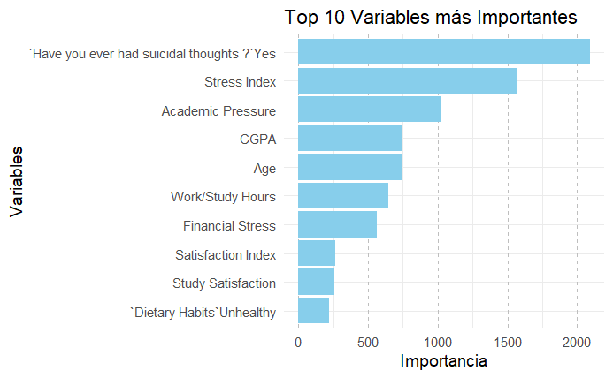

```r
library(ggplot2)
library(dplyr)

# Obtener las importancias de las características
feature_importances <- as.numeric(best_rf_model$importance)
features <- colnames(X)

importance_df <- data.frame(
  Feature = features,
  Importance = feature_importances
) %>%
  arrange(desc(Importance))

# Visualizar las 10 características más importantes
top_10_importance <- importance_df %>% slice(1:10)

ggplot(top_10_importance, aes(x = reorder(Feature, Importance), y = Importance)) +
  geom_bar(stat = "identity", fill = "skyblue") +
  coord_flip() +
  labs(
    title = "Top 10 Variables más Importantes",
    x = "Variables",
    y = "Importancia"
  ) +
  theme_minimal(base_size = 14) +
  theme(panel.grid.major.x = element_line(color = "gray", linetype = "dashed", size = 0.7))
```

```r
# Imprimir las 10 características más importantes
cat("Top 10 Variables más Importantes:\n")
```

```
Top 10 Variables más Importantes:
```

```r
print(top_10_importance)
```

| Feature | Importance |
| --- | --- |
| `Have you ever had suicidal thoughts ?`Yes | 2091.9098 |
| Stress Index | 1569.7139 |
| Academic Pressure | 1024.0735 |
| CGPA | 747.8432 |
| Age | 747.3932 |
| Work/Study Hours | 646.9213 |
| Financial Stress | 564.1433 |
| Satisfaction Index | 263.5306 |
| Study Satisfaction | 260.8289 |
| `Dietary Habits`Unhealthy | 221.2430 |

```r
NA
NA
NA
```